# Profitability and Marketing Performance Analysis for an E-Commerce Startup

Naver Smart Store | Feb 2026 – Apr 2026

# 1 About Suneung Chegam Research Lab

## 1.1 Company Overview

[figure not shown]

| Item | Details |
| --- | --- |
| Business age | Approximately 1 year |
| Core product | Notebooks designed in the same format as Korean CSAT exam papers |
| Competitive landscape | **No direct competitors — blue-ocean niche** |
| Sales channel | Naver Smart Store (no standalone online store) |
| Marketing approach | Instagram viral content → Naver search traffic → purchase |
| Primary customers | Exam-takers (17–19) + parents (46–50) |

**Business flow:**

```
Instagram content exposure
       ↓
Brand/product search
       ↓
Smart Store visit
       ↓
Purchase conversion (CVR 39% — Naver Search channel)
```

## 1.2 Business Pain Points & Project Overview

| Pain Point 1 | Pain Point 2 | Pain Point 3 |
| --- | --- | --- |
| **Unclear branding direction** | **Low repeat-purchase rate** | **Unclear profitability structure** |
| “How should the brand grow?” | “Customers buy once and do not return.” | “Should shipping fees be raised? Are margins sufficient?” |

**Project scope:**

- Analysis period: 2026.02.01 ~ 2026.04.30 (three months)
- Data source: Naver Smart Store Center
- Analysis tool: Tableau

# 2 Core KPI Framework

## 2.1 Rationale for KPI Selection

Pain Point → KPI mapping:

| Business issue | Selected KPI | Rationale |
| --- | --- | --- |
| Profitability stability | Net profit margin, contribution profit by product | Focus on actual profit rather than revenue alone |
| Shipping-cost efficiency | Shipping-cost share, AOV | Shipping cost relative to AOV matters more than the absolute amount |
| Repeat-purchase improvement | Repeat-purchase rate, funnel conversion rate | Retention is critical to profitability |
| Marketing direction | CVR by channel, RPV | Evidence is needed to prioritize high-ROI channels |
| Branding | Branded-keyword CVR, interested-customer growth | Assess whether branding translates into sales |

## 2.2 AS-IS / TO-BE

| Category | AS-IS (Current) | TO-BE (Target) |
| --- | --- | --- |
| Marketing | Reliance on Instagram viral traffic as a single channel | Combine Naver Search ads, Instagram, and Shopping optimization |
| Coupon strategy | Coupons issued without product-level targeting | Issue coupons on the 18th–20th of each month, targeting higher-margin options such as Lavender and Science |
| Repeat purchase | Customer drop-off after the first purchase (repeat-purchase rate 9.6–11.1%) | Build a repeat-purchase cycle with automated follow-up coupons |
| new product | Unsystematic launch timing and process | Saturday launch → Sunday coupon → D+4 reminder |
| Core products | White and Gray lead revenue but have the lowest margins due to residual packaging capacity | Use 10-unit bundles to improve box utilization and narrow margin differences across options |
| Profit structure | Many single-item orders create unused box capacity and shipping-cost inefficiency | Raise AOV above ₩20,000 and encourage 10-unit purchases to reduce shipping-cost share |

## 2.3 Overview of Three Dashboards

| Category | Dashboard 1 | Dashboard 2 | Dashboard 3 |
| --- | --- | --- | --- |
| Name | Profit Margin Analysis | Sales Operations Analysis | Product/Channel Strategy |
| Purpose | Assess profitability stability and identify core products | Diagnose and improve repeat-purchase performance | Develop marketing channel and product strategies |
| Type | **Dynamic** (monthly filter) | **Dynamic** (monthly filter) | **Static** (three-month cumulative) |
| Key Metrics | Net profit · margin · profit structure | Repeat-purchase rate · conversion funnel · purchase patterns | CVR · RPV · keywords · age × channel |
| Expected Impact | Select core products and define shipping-cost policy | Develop a retention strategy | Prioritize channel investment |

# 3 Data Sources & ERD

## 3.1 Data Sources

**Smart Store exported data**

```
├── Sales performance          (purchasers, payment amount, coupons, and refunds by date, weekday, and time)
├── Customer status          (total, new, and returning customers; cumulative interested customers)
├── Product performance          (purchases, payment amount, and refunds by product name and product ID)
├── product_shopping_behavior (product detail views and view-to-purchase conversion)
├── product_marketing_channel    (channel group/name and purchase contribution by product)
├── product_search_channel      (keywords, channels, and purchase contribution by product)
├── product_demographics      (purchase distribution by gender and age for each product)
├── product_customer_profile_occupation (buyer occupation distribution by product)
├── product_region          (regional purchase distribution by product)
├── all_channels           (visits, purchases, and revenue by channel group/name)
├── search_channels           (visits, CVR, and RPV by keyword)
├── demographics           (purchase distribution by gender, age, and channel)
├── shipping_statistics           (dispatch compliance and average delivery time by shipping type)
├── smartstore_purchase_confirmations (order ID, product ID, quantity, fees, and settlement amount)
├── smartstore_orders    (order status, product name, option, and buyer information)
├── smartstore_cancellations    (cancellation and refund details)
├── settlement_by_order      (fee breakdown and settlement status by order)
├── settlement_by_item    (fee details by item)
└── daily_settlement      (daily settlement amount and total fees)
```

**Company-provided cost data**

```
├── Purchase cost by product  (Math/other subjects ₩2,000; Chegam Pad ₩4,000 — based on product ID)
├── Packaging cost (A4: ₩250 per box, up to 10 units combined · Pad: ₩500 per unit)
└── Shipping cost (fixed at ₩2,500 per order)
```

## 3.2 Data Schema

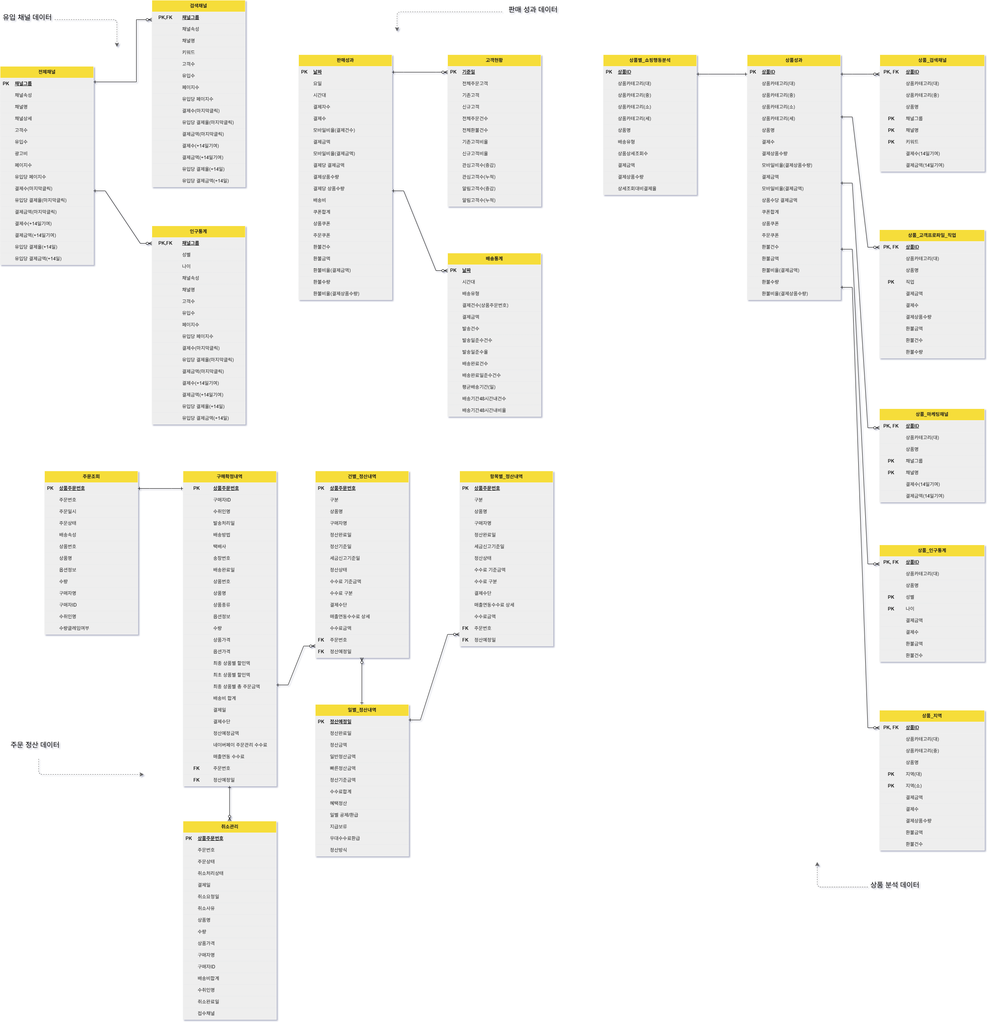

ERD Diagram

## 3.3 Tableau Calculated Fields (Margin Calculation)

### 3.3.1 Cost Structure

| Item | Product ID | Details |
| --- | --- | --- |
| Math notebook purchase cost | 11868416127 | ₩2,000 per unit |
| Other-subject notebook purchase cost | 13031541573 | ₩2,000 per unit |
| Chegam Pad purchase cost | 13318342227 | ₩4,000 per unit |
| A4 Packaging cost | — | Up to 10 units per box; ₩250 per box |
| Pad packaging cost | — | ₩500 per unit (packed separately from A4 products) |
| Shipping cost | — | Fixed at ₩2,500 per order |

**Combined-packaging policy:** A4 notebooks are combined in one box for every 10 units, while pads are packaged separately. Packaging cost is therefore calculated by product type.

### 3.3.2 Tableau Calculated Fields

The dashboard uses a five-layer calculation structure covering product classification, packaging cost, revenue and fees, margin calculation, and KPI aggregation.

**View Tableau Calculated Fields**

```sql
// ════════════════════════════════════════
// LAYER 1. Product classification and cost
// ════════════════════════════════════════

// 1. Product type
// Classify Pad vs. A4 by product ID
IF STR([Product ID]) = "13318342227"
THEN "Pad"
ELSE "A4"
END

// 2. Purchase cost
// Pad ₩4,000 / A4 (Math and other subjects) ₩2,000
IF STR([Product ID]) = "13318342227"
THEN 4000
ELSE 2000
END

// 3. Product cost  [row level]
[Purchase cost] * [Quantity]

// 4. Product cost by order  [FIXED]
// Aggregate by order ID to prevent duplication
{ FIXED [Order ID] : SUM([Product cost]) }


// ════════════════════════════════════════
// LAYER 2. Packaging cost
// A4: one box per 10 units; Pad: packaged separately
// ════════════════════════════════════════

// 5. A4 order quantity  [FIXED]
{ FIXED [Order ID] :
  SUM(IF [Product type] = "A4" THEN [Quantity] ELSE 0 END) }

// 6. Pad order quantity  [FIXED]
{ FIXED [Order ID] :
  SUM(IF [Product type] = "Pad" THEN [Quantity] ELSE 0 END) }

// 7. A4 Packaging cost
// One box per 10 units (₩250), rounded up using CEILING
IF [A4 order quantity] > 0
THEN CEILING([A4 order quantity] / 10) * 250
ELSE 0
END

// 8. Pad packaging cost
// ₩500 per Pad
[Pad order quantity] * 500

// 9. Total cost
[Product cost by order] + [A4 Packaging cost] + [Pad packaging cost]


// ════════════════════════════════════════
// LAYER 3. Revenue and costs (Naver Smart Store)
// ════════════════════════════════════════

// 10. Revenue by order  [FIXED]
{ FIXED [Order ID] : SUM([Final total order amount by product]) }

// 11. Shipping cost by order  [FIXED]
// Fixed at ₩2,500 per order
{ FIXED [Order ID] : MIN(2500) }

// 12. Revenue-linked fees by order  [FIXED]
{ FIXED [Order ID] : SUM([Revenue-linked fees]) }

// 13. Naver Pay order-management fees by order  [FIXED]
{ FIXED [Order ID] : SUM([Naver Pay order-management fees]) }


// ════════════════════════════════════════
// LAYER 4. Margin calculation
// ════════════════════════════════════════

// 14. Margin by order
[Revenue by order]
- [Total cost]
- [Shipping cost by order]
- [Revenue-linked fees by order]
- [Naver Pay order-management fees by order]

// 15. Margin  [row level / format: percentage]
[Margin by order] / [Revenue by order]

// 16. Margin by product  [weighted average reflecting sales volume]
SUM([Margin by order]) / SUM([Revenue by order])

// 17. Margin by option  [LOD — Smart Store product name + option level]
{ FIXED [Smart Store product name], [Option name] :
  SUM([Margin by order]) / SUM([Revenue by order]) }


// ════════════════════════════════════════
// LAYER 5. KPI cards
// Use FIXED by order ID + MIN to prevent duplicate aggregation
// ════════════════════════════════════════

// 18. Net profit card
SUM({ FIXED [Order ID] : MIN([Margin by order]) })

// 19. Average margin card  [format: percentage]
SUM({ FIXED [Order ID] : MIN([Margin by order]) })
/
SUM({ FIXED [Order ID] : MIN([Revenue by order]) })
```

# 4 Dashboard 1 — Profit Margin Analysis

## 4.1 Dashboard Views

### 4.1.1 February Profit Margin Dashboard

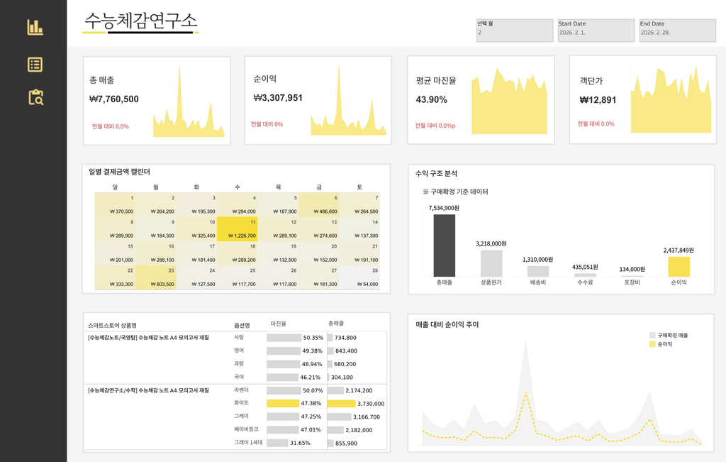

Profit Margin Analysis Dashboard — February 2026

### 4.1.2 March Profit Margin Dashboard

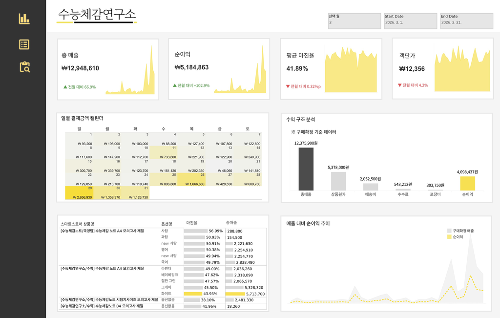

Profit Margin Analysis Dashboard — March 2026

### 4.1.3 April Profit Margin Dashboard

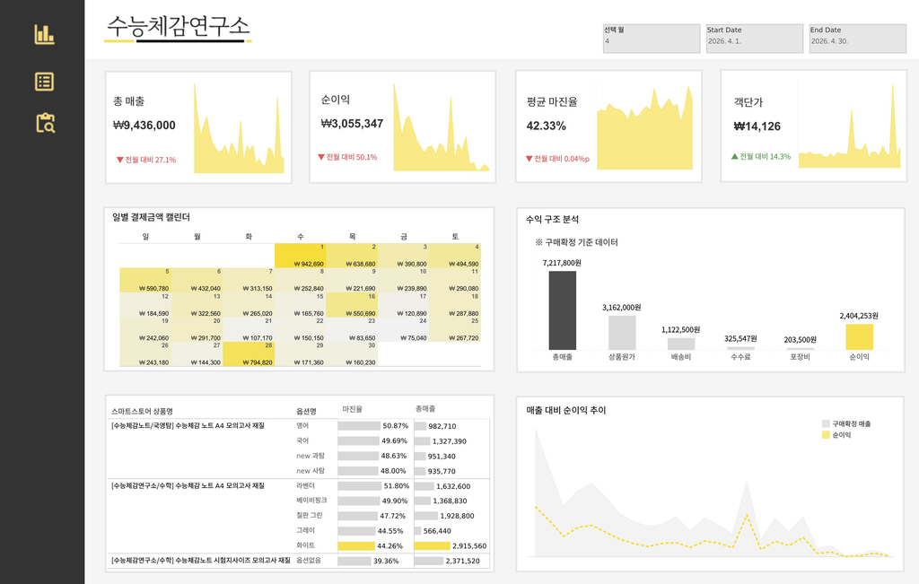

Profit Margin Analysis Dashboard — April 2026

## 4.2 Three-month Profit Structure Comparison

| Metric | February | March | April | Trend |
| --- | --- | --- | --- | --- |
| Total revenue | ₩7,760,500 | ₩12,948,610 | ₩9,436,000 | March peak |
| Net profit | ₩3,307,951 | ₩5,184,863 | ₩3,055,347 | Same pattern |
| Margin | 43.90% | 41.89% | 42.33% | **Stable** |
| AOV | ₩12,891 | ₩12,356 | ₩14,126 | April high |
| Purchasers | 535 customers | 832 customers | 539 customers | March peak |
| Shipping-cost share | 17.4% | 16.6% | 15.6% | Improving |

**Profit-structure waterfall (March):**

```
Total revenue  ₩12,375,900  (100%)
  - Product cost  ₩5,378,000  (43.5%)
  - Shipping cost    ₩2,052,500  (16.6%)
  - fees      ₩543,213  ( 4.4%)
  - Packaging cost   ₩303,750  ( 2.5%)
  = Net profit    ₩4,098,437  (33.1%)
```

**Key diagnosis:** Margins remained stable at 40–44% over three months, indicating a fundamentally healthy profit structure. The relatively high shipping-cost share is driven by low AOV; raising AOV above ₩20,000 should take priority over increasing shipping fees.

## 4.3 Key Anomaly — “Record-High AOV, but Revenue and Net Profit Fell Sharply”

|  | March | April | Interpretation |
| --- | --- | --- | --- |
| Purchasers | 832 customers | 539 customers | **-35.2% Sharp decline** |
| AOV | ₩12,356 | ₩14,126 | **+14.3% Increase** |
| Total revenue | ₩12,948,610 | ₩9,436,000 | -27.1% Decline |

> **In April, fewer customers purchased, but those who did spent more.**  
> This suggests stronger high-intent purchasing (repeat or bundle purchases) but weaker new-customer conversion.

## 4.4 Product Margin Matrix — “High Sales ≠ High Profit”

```
              High margin (50%+)
                    ↑
  Lavender(April 51.8%) │  Social Studies(March 56.99%) ★Coupon priority
  Baby Pink        │  new Science(52.16%)  ★Coupon priority
──────────────────────────────────→ High revenue
  Chalkboard Green          │  White ← revenue #1, combined packaging lower packaging efficiency
  Baby Pink        │  Gray ← High revenue, combined packaging lower packaging efficiency
              Low margin (40% range)
```

**Three-month margin summary by option:**

[output not shown]

**Strategic recommendation:** White and Gray were already high-volume core options before coupons were issued. Additional coupons may therefore discount purchases that would have occurred anyway, reducing margins. Prioritize coupons for lower-volume options with greater margin headroom to stimulate incremental purchases and balance sales across options.

## 4.5 4.5 Shipping-Cost Structure & AOV Strategy

Shipping cost ₩2,500 → ₩3,200 under consideration for increase

**Shipping-cost share vs. industry benchmarks:**

| Category | Shipping-cost share | Description |
| --- | --- | --- |
| General e-commerce average | 3~8% | Large platforms / in-house logistics |
| Small Smart Store sellers | 8~15% | Individual/small-business sellers |
| **Suneung Chegam Research Lab** | **15.6~17.4%** | Current level |

The product is low-priced and relatively bulky, which structurally increases shipping-cost share.

For products with an AOV of ₩12,000–14,000, a shipping fee of ₩3,000–3,500 can account for roughly one quarter of the selling price. This makes the shipping-cost share appear structurally high even when the absolute shipping fee is not unusual.

→ Shipping cost is not inherently expensive; rather, **the low unit price makes shipping appear disproportionately large**

**Recommended direction:** Rather than increasing shipping fees, introduce a **free-shipping threshold around ₩20,000** and encourage bundled purchases to raise AOV.

# 5 Dashboard 2 — Sales Operations Analysis

## 5.1 Dashboard Views

### 5.1.1 February Sales Operations Dashboard

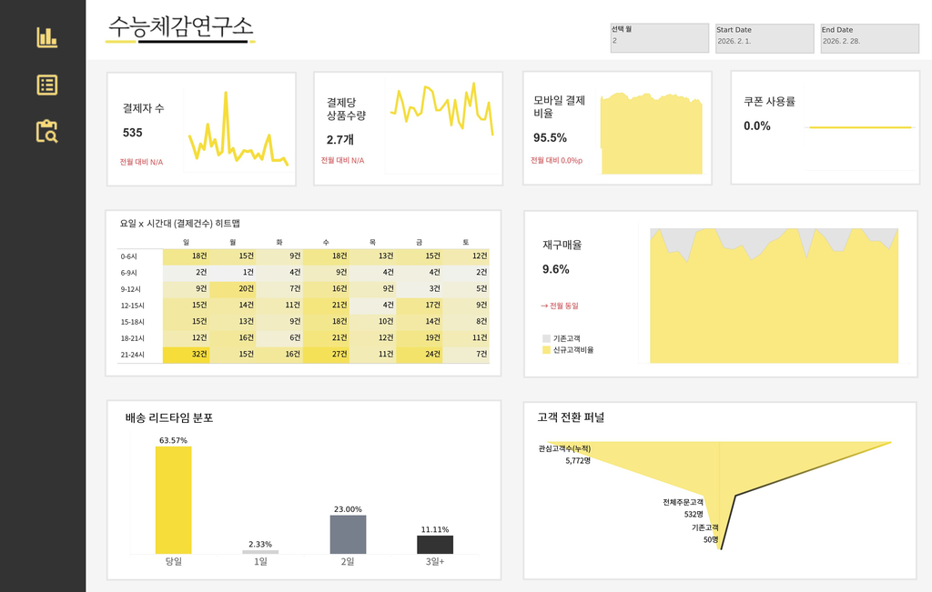

Sales Operations Analysis Dashboard — February 2026

### 5.1.2 March Sales Operations Dashboard

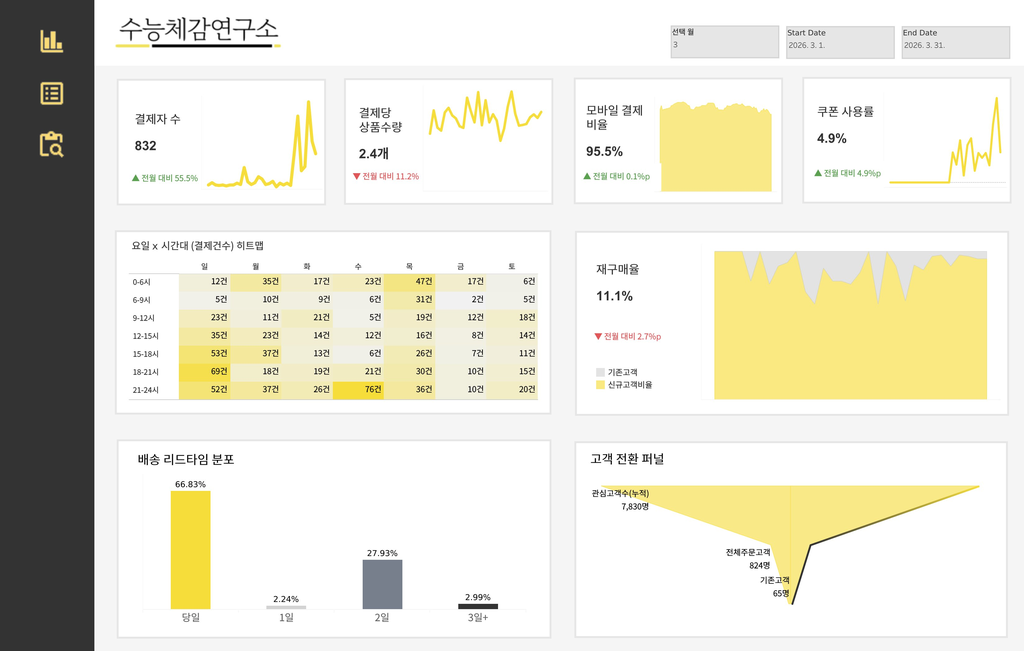

Sales Operations Analysis Dashboard — March 2026

### 5.1.3 April Sales Operations Dashboard

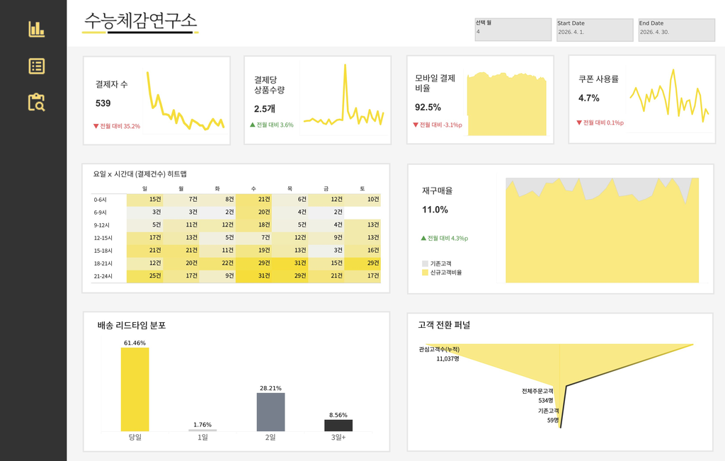

Sales Operations Analysis Dashboard — April 2026

## 5.2 Repeat-Purchase Structure — Three-month Trend

**Joint analysis of repeat-purchase and funnel conversion rates:**

[output not shown]

**Funnel conversion rate:**

```
February: 5,772 → 535 =  9.3%
March: 7,830 → 832 = 10.6%
April: 11,037 → 539 =  4.9% ← lowest observed
```

**Key issue:** April recorded the highest number of interested customers (11,037), yet the purchase conversion rate fell to **4.9%, the lowest of the three months**. → Awareness is increasing, but a **first-purchase barrier** remains

## 5.3 Customer Conversion Funnel Analysis

Three-month trend in interested customers: **5,772 → 7,830 → 11,037** (steady increase)  
However, purchasers changed from **535 → 832 → 539**, showing a sharp decline after March.

> **“Traffic is growing, but conversion is not”**  
> Brand awareness is building, but conversion friction remains  
> → First-purchase incentives (discount coupons or trial bundles) are needed

## 5.4 Identifying High-Conversion Purchase Windows

| Day | Peak Purchase Window | Representative Orders | Purchase Pattern |
| --- | --- | --- | --- |
| **Sunday** | **18–21h** | 56 orders (Mar 29) | Weekend evening planned purchases |
| **Thursday** | **0–6h** | 47 orders (March) | Late-night impulse purchases |
| **Wednesday** | **21–24h** | 59 orders (Mar 25–31) | Weekday late-night purchases |
| Saturday | 9~12h + 21~24h | Bimodal pattern | Morning and late-night split |

**Optimal content publishing schedule:**

```
Monday: no scheduled content
Tuesday: —
Wednesday 9 PM: publish a post → drive purchases before midnight
Thursday 11 PM: publish a Story → drive late-night purchases
Friday: —
Saturday 9 AM: announce new product/event
Sunday 5 PM: coupon-expiry reminder → target the 6–9 PM purchase peak
```

# 6 Dashboard 3 — Product/Channel Strategy Analysis

## 6.1 Dashboard Views

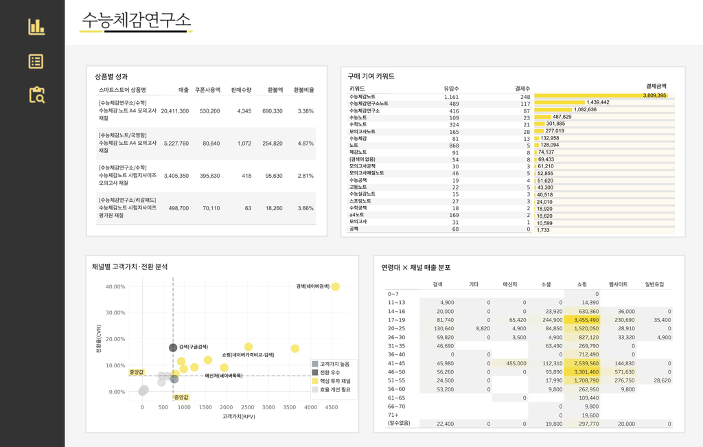

Product/Channel Strategy Analysis Dashboard — Three-Month Cumulative View

## 6.2 Customer Value & Conversion by Channel

**Four-quadrant channel positioning:**

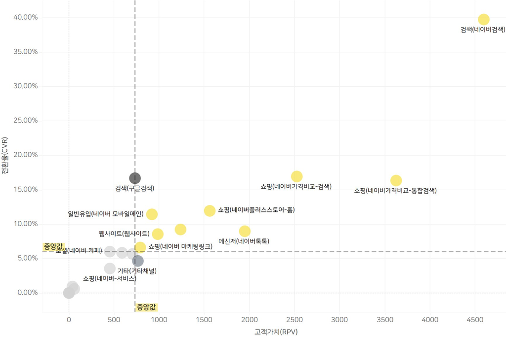

Channel-Level Customer Value & Conversion Analysis — RPV × CVR Scatter Plot

**Channel investment priority:**

| Rank | Channel | Rationale |
| --- | --- | --- |
| **1st** | Naver Search Ads | RPV ₩4,592 + CVR 39%; captures demand generated by Instagram viral traffic |
| **2nd** | Naver Shopping optimization | RPV 2,400~3,600 / can improve without additional media spend |
| **3rd** | Instagram | Maintain current viral reach + optimize content timing |
| Reduce | Google Ads | RPV 735 — 6× lower than Naver |
| Discontinue | Social communities / other | CVR·RPV both below median |

**Key finding:** Customers who saw Instagram content and then searched for the brand directly on Naver showed the strongest purchase volume, spending, and conversion.  
→ **Data evidence that the current marketing strategy (Instagram viral reach → Naver Search traffic) is working**

## 6.3 Purchase-Contributing Keyword Analysis

| Keyword | Visits | Purchases | Revenue | CVR |
| --- | --- | --- | --- | --- |
| Suneung Chegam Notebook (Korean branded query) | 1,161 | 248 | ₩3,809,395 | 21.4% |
| Suneung Chegam Research Lab Notebook (Korean branded query) | 489 | 117 | ₩1,439,442 | **23.9%** |
| Suneung Chegam Research Lab | 416 | 87 | ₩1,082,636 | 20.9% |
| CSAT Notebook (Korean query) | 109 | 23 | ₩487,829 | 21.1% |
| Math Notebook | 324 | 21 | ₩301,885 | 6.5% |

**Evidence for branding investment:** “Suneung Chegam Research Lab Notebook (Korean branded query)” CVR 23.9% > “Suneung Chegam Notebook (Korean branded query)” CVR 21.4%  
→ **Customers searching the brand name convert at a higher rate, indicating that branding is directly associated with revenue**

## 6.4 Revenue Distribution by Age × Channel

| Age Group | Shopping | Search | Website | Characteristic |
| --- | --- | --- | --- | --- |
| 17~19 | **₩3,455,490** | ₩81,740 | ₩230,690 | Shopping is overwhelmingly dominant |
| 46~50 | **₩3,301,460** | ₩56,260 | ₩571,630 | Likely parent purchases |
| 20~25 | ₩1,520,050 | ₩130,640 | ₩28,910 | University students / repeat test-takers |

**Dual-Target Strategy:** - **Exam-takers (17–19):** Focus on Shopping/Instagram → empathy-focused content for students - **Parents (46–50):** Focus on the Shopping channel → position products as a “gift for a child”

# 7 Business Insights — Deep Dives into Key Dates

## 7.1 Insight 1 | Feb 11 (Wed) — Seasonality Effect

**₩1,226,700 (highest single-day revenue in February)**

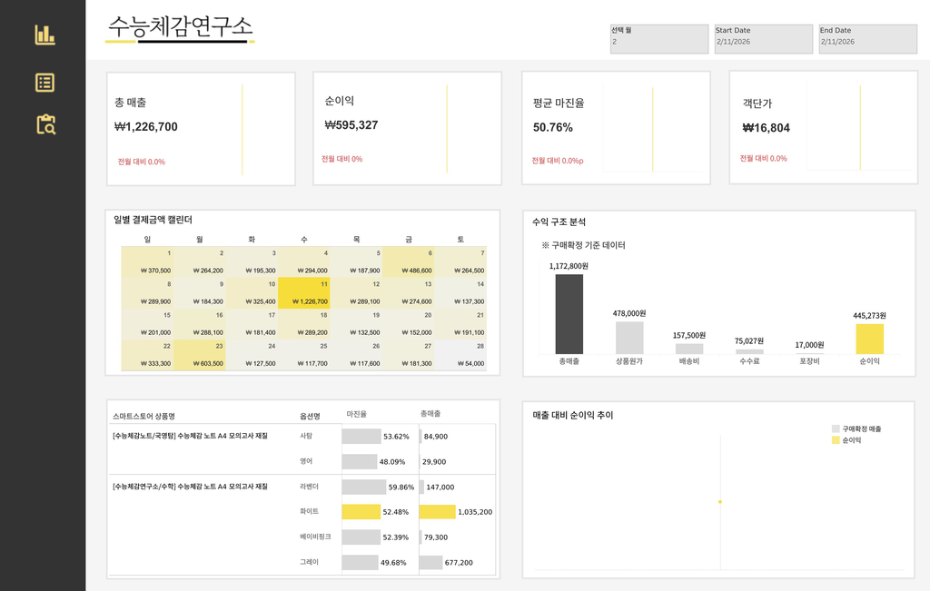

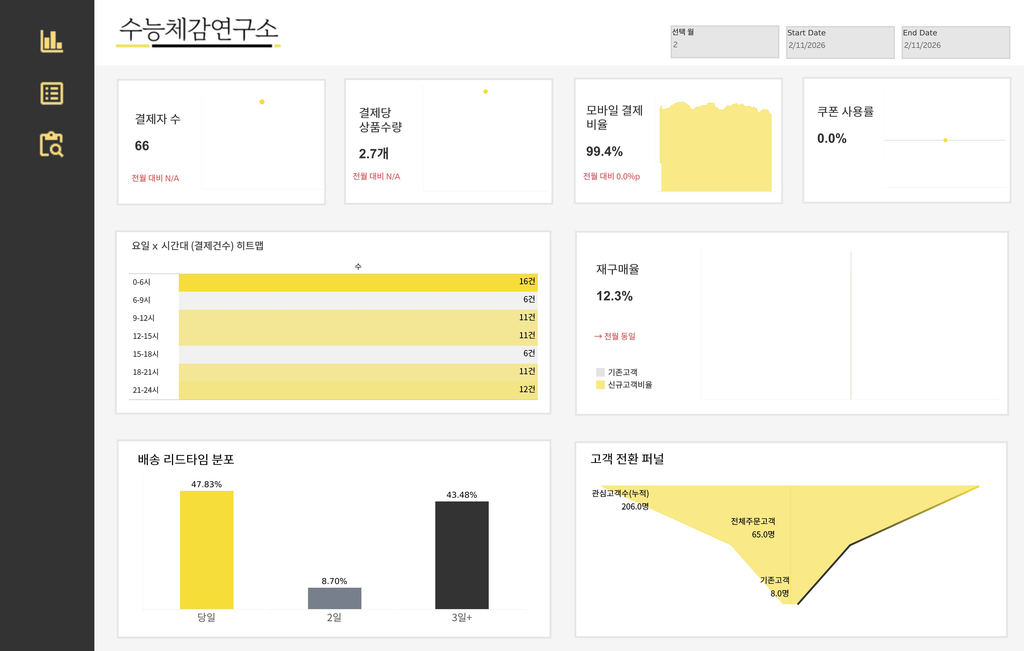

| Metric | Feb 11 | February daily average | Comparison |
| --- | --- | --- | --- |
| Total revenue | ₩1,226,700 | ₩277,160 | **+343%** |
| Net profit | ₩595,327 | ₩118,141 | **+404%** |
| Average margin | **50.76%** | 43.90% | **+6.86%p** |
| AOV | **₩16,804** | ₩12,891 | **+30.4%** |
| Purchasers | 66 | 19.1/day | **+245%** |
| Coupon usage rate | **0.0%** | 0.0% | Same |
| Mobile payments | **99.4%** | 95.5% | +3.9%p |
| Repeat-purchase rate | **12.3%** | 9.6% | +2.7%p |

**Results of initial hypothesis tests:**

| Hypothesis | Result | Assessment |
| --- | --- | --- |
| Seasonal demand surge immediately after the Lunar New Year holiday | Purchasers 3.5×, conversion rate 3.4× | Supported |
| A demand spike can occur without coupons | 0% coupon usage with an even higher margin | Supported |
| Increase in bundle purchases | Average units per purchase unchanged (2.7) | Rejected |
| Higher share of repeat customers | 12.3% (slightly above the typical 9.6%) | Partially supported |

**New key finding:** “AOV (+30%), margin (+6.86 pp), and purchasers (+245%) all increased simultaneously.” Identifying how often such dates occur during the year should be the starting point for the marketing calendar.

> **One-line takeaway:**  
> “Feb 11 delivered the highest margin without coupons; timing campaigns around the resumption of exam preparation may be more powerful than discounting.”

## 7.2 Insight 2 | Mar 26 (Thu) — Coupon Seeding Day

**₩1,666,680 (second-highest daily revenue in March)**

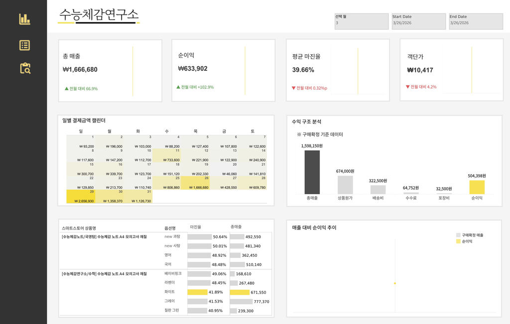

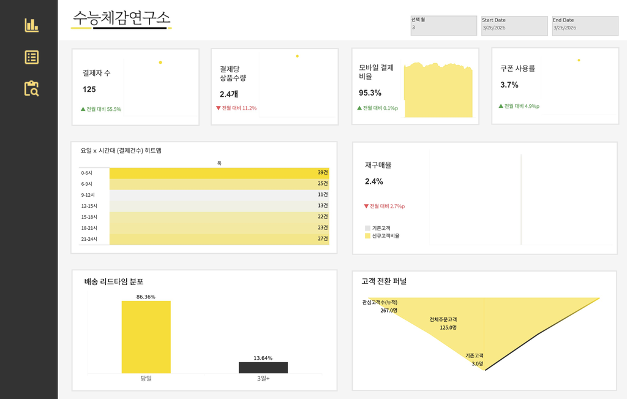

**Feb 11 vs. Mar 26 — Direct Comparison:**

| Metric | Feb 11 | Mar 26 | Difference |
| --- | --- | --- | --- |
| Total revenue | ₩1,226,700 | ₩1,666,680 | +35.9% |
| Net profit | ₩595,327 | ₩633,902 | +6.5% |
| **Average margin** | **50.76%** | **39.66%** | **▼11.1%p** |
| **AOV** | **₩16,804** | **₩10,417** | **▼37.9%** |
| Purchasers | 66 customers | 125 customers | +89.4% |
| Coupon usage rate | 0.0% | **3.7%** | First appearance |
| Repeat-purchase rate | 12.3% | **2.4%** | **▼9.9%p** |

**Purchase Time Distribution (Mar 26):**

[output not shown]

**Product Mix Sold That Day:**

Korean/English/Social Studies A4 options (higher-margin group):

| Option | margin | revenue |
| --- | --- | --- |
| New Science | 50.64% | ₩492,550 |
| New Social Studies | 50.01% | ₩481,340 |
| English | 48.92% | ₩362,450 |
| Korean | 48.48% | ₩510,140 |

Math A4 options (lower-margin group):

| Option | margin | revenue | Notes |
| --- | --- | --- | --- |
| Baby Pink | 49.06% | ₩168,610 |  |
| Lavender | 48.45% | ₩267,480 |  |
| **White** | **41.89%** | **₩671,550** | ← 2nd in revenue, lower-margin tier |
| **Gray** | **41.53%** | **₩777,370** | ← revenue #1, margin lower tier |
| Chalkboard Green | 40.95% | ₩239,300 |  |

**Key finding:** Revenue was among the highest observed, but the average margin was among the lowest. The main reason was that lower-margin White and Gray options accounted for a large share of that day’s sales. In this setting, coupons appear more useful for **lowering the first-purchase barrier** than for driving repeat purchases.

**Shipping Lead-Time Anomaly:**

- Same-day shipping: **86.36%** (vs. 47.83% on Feb 11, +38.5 pp)
- 3+ days: 13.64% (no one- or two-day shipments)
- → Order concentration created a polarized pattern: many orders shipped the same day, while some were delayed three days or more.

**Refined Strategy:**

| Current Issue | Cause | Recommended Action |
| --- | --- | --- |
| Coupons attracted new customers, but repeat-purchase rate fell to 2.4% | Coupons were concentrated on first purchases | Shift follow-up coupons toward **second purchases** |
| Coupons concentrated on White and Gray | Lower-margin options dominated sales | Prioritize **Lavender and New Science** |

**“High Sales ≠ High Profit” — Same-Day Comparison (March 26)**

```
Lavender  margin 48.45% ← higher-priority option
White     margin 41.89% ← high revenue, lower margin
Gray      margin 41.53% ← highest revenue, lower margin

→ If the same coupon budget had been prioritized toward Lavender and New Science instead of White and Gray,
  estimated net profit could have increased from ₩633,902 to approximately ₩750,000–800,000.
```

> **One-line takeaway:**  
> “Mar 26 generated very high revenue, but margins were among the lowest observed. Coupons helped drive traffic, yet they were concentrated on lower-margin products. Future promotions should prioritize higher-margin options such as Lavender and Science.”

## 7.3 Insight 3 | Mar 29 (Sun) — Coupon Harvest Day

**₩2,656,930 (highest single-day revenue across the three-month period)**

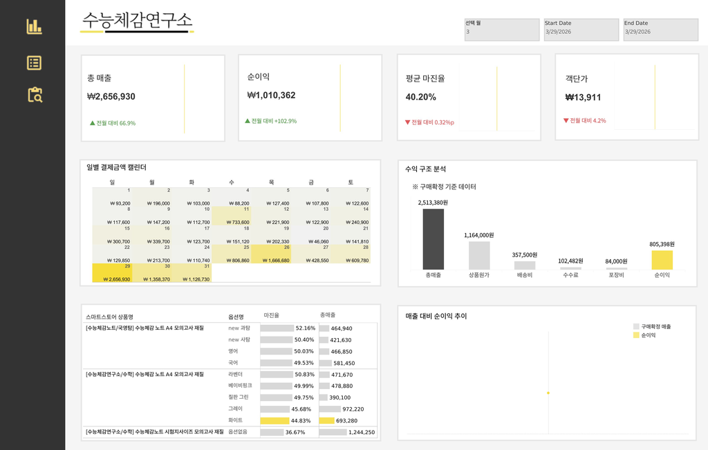

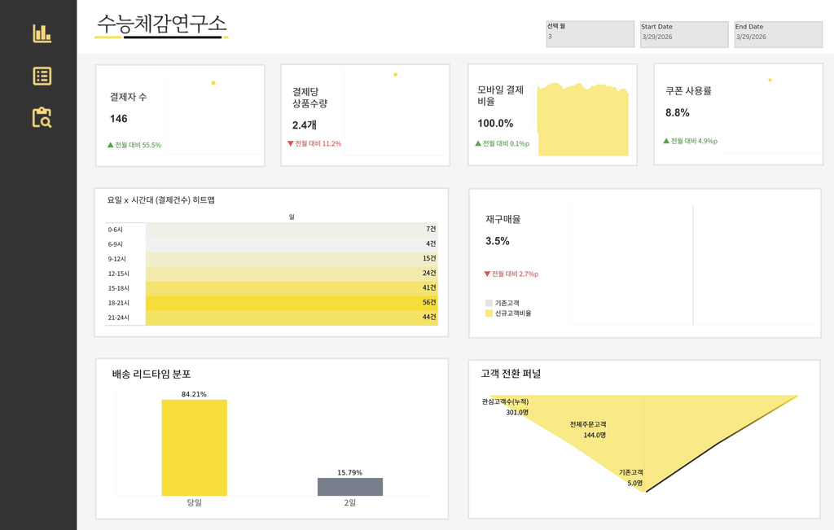

**Comparison of Three Notable Days:**

| Metric | Feb 11 (seasonality) | Mar 26 (coupon seeding) | **Mar 29 (harvest)** | March daily average |
| --- | --- | --- | --- | --- |
| Total revenue | ₩1,226,700 | ₩1,666,680 | **₩2,656,930** | ₩417,697 |
| Net profit | ₩595,327 | ₩633,902 | **₩1,010,362** | — |
| Average margin | 50.76% | 39.66% | 40.20% | 41.89% |
| AOV | ₩16,804 | ₩10,417 | ₩13,911 | ₩12,356 |
| Purchasers | 66 | 125 | **146** | 26.8 |
| Coupon usage rate | 0.0% | 3.7% | **8.8%** | 4.9% |
| Repeat-purchase rate | 12.3% | 2.4% | 3.5% | 11.1% |
| Mobile payments | 99.4% | 95.3% | **100.0%** | 95.5% |

**Purchase-Time Comparison (Mar 26 vs. Mar 29):**

| Time Window | Mar 26 (Thu) | Mar 29 (Sun) | Interpretation |
| --- | --- | --- | --- |
| 0–6h | **39 orders** | 7 orders | Thursday: early-morning purchases |
| 18–21h | 23 orders | **56 orders** | Sunday: concentrated evening purchases |
| 21–24h | 27 orders | 44 orders | — |

**“Thursday Coupon → Sunday Surge” Pattern:** **“Thursday coupon → Sunday surge” playbook:**

| Date | Role | Revenue |
| --- | --- | --- |
| Mar 26 (Thu) | First coupon exposure / seeding | ₩1,666,680 |
| 3/27~28 | word of mouth·Instagram diffusion | — |
| **Mar 29 (Sun)** | **Harvest day** | **₩2,656,930** |

**Product Mix Sold That Day:**

Korean/English/Social Studies A4 options (generally healthy margins):

| Option | Margin | Revenue |
| --- | --- | --- |
| New Science | 52.16% | ₩464,940 |
| English | 50.03% | ₩466,850 |
| New Social Studies | 50.40% | ₩421,630 |
| Korean | 49.53% | ₩581,450 |

Math A4 + Exam-Paper Size:

| Option | Margin | Revenue | Notes |
| --- | --- | --- | --- |
| **Lavender** | **50.83%** | ₩471,670 | ← highest margin |
| Baby Pink | 49.99% | ₩478,880 |  |
| Chalkboard Green | 49.75% | ₩390,100 |  |
| Gray | 45.68% | ₩972,220 |  |
| White | 44.83% | ₩693,280 | high revenue, lower-margin tier |
| **Exam-Paper Size** | **36.67%** | **₩1,244,250** | 46.8% of that day’s revenue |

**Customer Conversion Funnel:**

- 301 interested customers → 144 purchasers → 5 returning customers
- Conversion rate: 144/301 = **47.8%**, the highest among the three notable days
- Repeat-purchase rate: 3.5% → new customers dominated (96.5%)
- → This was the day when a large number of already-aware prospects converted into first-time buyers.

**Exam-Paper Size as a Key Product:** A single option generated ₩1,244,250, accounting for **46.8% of the day’s revenue**.  
Despite its low 36.67% margin, it produced a strong sales response when paired with coupons.

**Exam-Paper Size strategy:** - Use Exam-Paper Size purchases to cross-sell higher-margin Lavender/Science options. - Consider bundle configurations such as **Exam-Paper Size + Korean/English/Social Studies set**. - Use the lower-margin Exam-Paper Size as an **anchor product to raise AOV**.

**Summary of the Three Notable Days — Best Strategy by Revenue Pattern:**

| Type | Representative Day | Characteristic | Recommended Strategy |
| --- | --- | --- | --- |
| **Seasonality-driven** | Feb 11 | Highest margin; coupons unnecessary | Content aligned with the exam-preparation calendar |
| **Coupon-seeding** | Mar 26 | Surge in new customers | Thursday coupon announcement |
| **Coupon-harvest** | **Mar 29** | **Highest absolute revenue** | **Sunday evening expiry reminder** |

> **One-line takeaway:**  
> “The highest-revenue day in March was Mar 29, not Mar 26. The coupon effect peaked three days after initial exposure, on Sunday evening, with the newly launched Exam-Paper Size product as the main driver.”

## 7.4 Insight 4 | 11-Day Coupon Cycle Pattern (Mar 18–31)

**Coupon Cycle Timeline:**

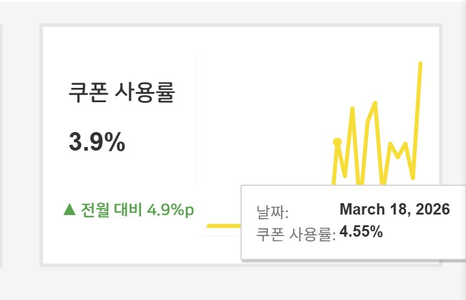

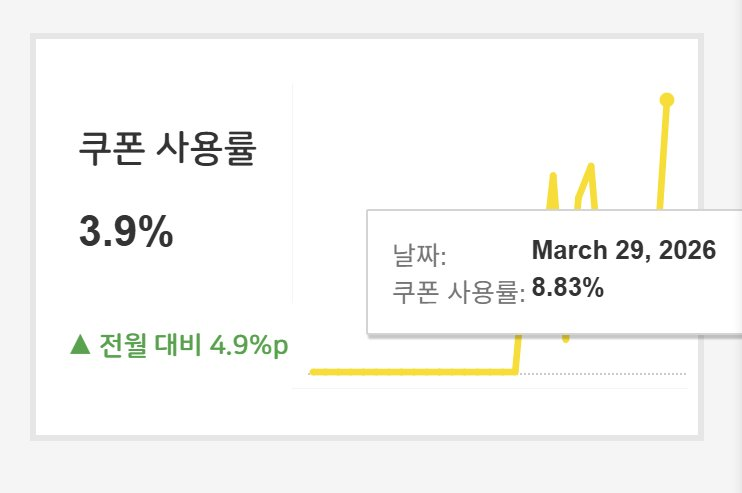

*Left: Mar 18, first coupon issuance (usage rate 4.55%) / Right: Mar 29, peak coupon usage (8.83%)*

| Date | Coupon Usage Rate | Event | Interpretation |
| --- | --- | --- | --- |
| Mar 1–17 | 0% | No coupons | Organic-purchase period |
| **Mar 18 (Wed)** | **4.55%** | **Coupon issuance begins** | Immediate first-day usage |
| Mar 19–25 | Fluctuating | Coupon awareness diffuses | Monthly-average rate settles near 3.9% |
| Mar 26 (Thu) | 3.7% | Coupon + new-customer surge | 125 purchasers |
| **Mar 29 (Sun)** | **8.83%** | **Peak coupon usage** | 146 purchasers; highest revenue |
| 3/30~31 | Decline | coupon coupon depletion | cycle end |

**Key Metrics for the Final Week (Mar 25–31):**

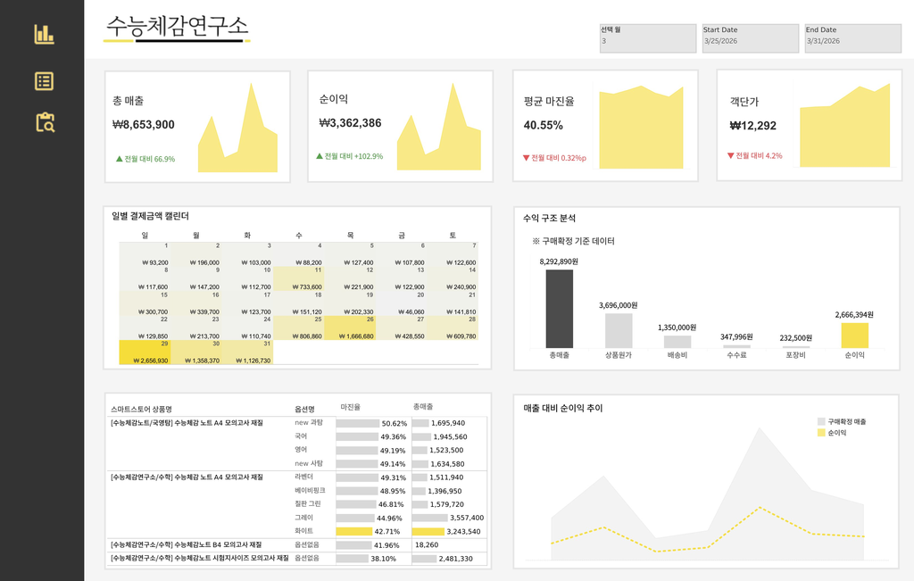

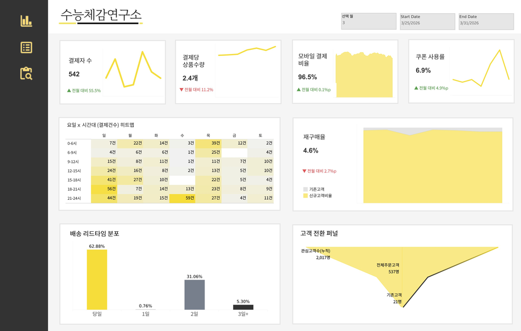

*Left: Mar 25–31 Profit Margin Dashboard / Right: Mar 25–31 Sales Operations Dashboard*

[output not shown]

**Final-Week Product Mix Analysis:**

[output not shown]

**Peak Purchase Windows by Day — Final Week:**

| Time Window | Sun | Mon | Tue | Wed | Thu | Fri | Sat |
| --- | --- | --- | --- | --- | --- | --- | --- |
| 0-6h | 7 | 22 | 14 | 3 | **39** | 12 | 2 |
| 15-18h | **41** | 27 | 10 | 0 | 22 | 5 | 4 |
| 18-21h | **56** | 7 | 14 | 13 | 23 | 8 | 9 |
| 21-24h | 44 | 19 | 15 | **59** | 27 | 4 | 11 |

**11-Day Coupon Cycle Pattern:**

```
Issue date (3/18) ──────── Peak usage date (3/29)
     │                      │
   4.55%                  8.83%
(Release of pent-up demand)       (Concentrated use after diffusion)
     └──────── 11 days ────────┘
```

→ A **14-day coupon validity window** would comfortably cover the observed 11-day cycle.

**Coupon Cycle × Content Calendar:**

```
D-11 (coupon issuance): Instagram post announcing the coupon
D-8  (Wednesday night): Instagram Story reminder (leveraging the Wed 21–24h pattern: 59 orders)
D-4  (Thursday early morning): pre-midnight post (leveraging the Thu 0–6h pattern: 39 orders)
D-0  (Sunday evening): "Ends today" urgency Story (leveraging the Sun 18–21h pattern: 56 orders)
```

**Coupon Operations Playbook:**

| Scenario | Recommended Issue Date | Rationale |
| --- | --- | --- |
| Regular monthly cycle | **18th–20th of each month** | Position peak usage near month-end, ~11 days later |
| Seasonal campaign | ~10 days before the seasonal event | Align peak coupon use with the seasonal demand peak |
| 100 days before the CSAT | D-110 | Target peak coupon usage around D-100 |

**Redesign coupon targeting:**

**Current issue:** Coupons were concentrated on White, Gray, and Exam-Paper Size, all relatively low-margin options (roughly 38–45%).

**Recommended redesign:** Issue dedicated coupons for Lavender, New Science, and Baby Pink, where margins are roughly 49–52%.  
Exclude White and Gray from priority couponing or apply a lower discount rate.

**Link to the Repeat-Purchase Problem:**

- Final-week repeat-purchase rate was only 4.6%, suggesting that many new customers purchased once and did not return.
- Design an automated **second-purchase coupon three weeks after the first purchase**.
- If some of the 146 purchasers from Mar 29 can be retained, the April repeat-purchase rate could improve.

> **One-line takeaway:**  
> “Coupon usage peaked 11 days after issuance (Mar 18 → Mar 29), and 67% of March revenue was concentrated in the final seven days. Fixing coupon issuance around the 18th–20th of each month may reproduce a similar pattern, but the timing effect should be validated over an additional 2–3 months.”

## 7.5 Supporting Insight | Three-month Cumulative Product Performance (Dashboard 3)

**Three-Month Cumulative Product Performance:**

| Product | Three-Month Revenue | Units Sold | Coupon Spend | Refund Amount | Refund Rate |
| --- | --- | --- | --- | --- | --- |
| [Math] Suneung Chegam A4 Mock-Exam Notebook | **₩20,411,300** | 4,345 | ₩530,200 | ₩690,330 | 3.38% |
| [Korean/English/Social Studies] Suneung Chegam A4 Mock-Exam Notebook | ₩5,227,760 | 1,072 | ₩80,640 | ₩254,820 | **4.87%** |
| [Math] Suneung Chegam Exam-Paper Size Notebook | ₩3,405,350 | 418 | **₩395,630** | ₩95,630 | **2.81%** |
| [Legal Pad] Suneung Chegam Exam-Paper Size Notebook | ₩498,700 | 63 | ₩70,110 | ₩18,260 | 3.66% |

**Interpretation by Product:**

**① Coupon Concentration on Exam-Paper Size**  
Coupon spend as a share of Exam-Paper Size revenue: ₩395,630 / ₩3,405,350 = **11.6%**, about 4.5× the Math A4 ratio (2.6%).  
→ This suggests coupons were more effective at **lowering the first-purchase barrier for a new product** than at driving repeat purchases of established products.

**② Refund Rate as a Quality Signal**  
- Korean/English/Social Studies A4: refund rate **4.87%**, the only product group above 4% → monitor for possible expectation mismatch. - Exam-Paper Size: **2.81%**, the lowest refund rate → encouraging satisfaction despite being a new product.

**③ Lowest Coupon Efficiency: Legal Pad**  
Legal Pad coupon spend (₩70,110) was high relative to its revenue (₩498,700).  
→ **Exclude it from coupon priority or reposition it within bundles.**

**Coupons should not simply be allocated to products that already sell well; they should be used to reduce the first-purchase barrier for products the business wants to grow.**

**Replication Formula:**

| Item | Details |
| --- | --- |
| Timing | 2–3 weeks after a new-product launch, once awareness has formed |
| Target | Higher-priced products with low refund rates |
| Method | Send Exam-Paper Size coupons to Math A4 purchasers (cross-selling) |
| Expected Impact | Reproduce a high-revenue day similar to Mar 26 while accelerating early sales of the new product |

**Three-Day New-Product Launch Timeline:**

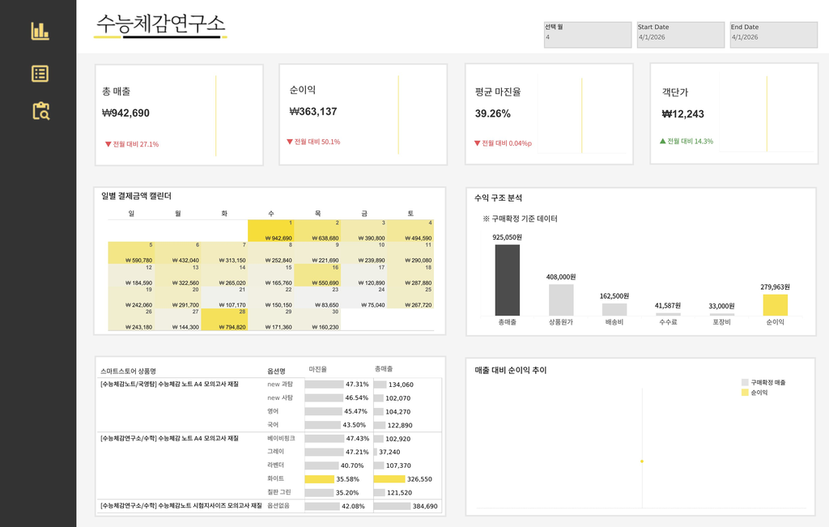

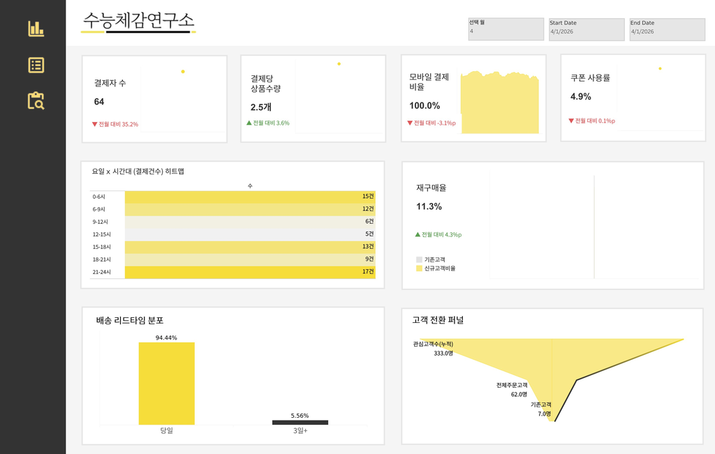

*Left: Apr 1 (D+4) Profit Margin Dashboard / Right: Apr 1 (D+4) Sales Operations Dashboard*

| Date | Revenue | Purchasers | Exam-Paper Size Revenue | Coupon Usage | Margin | Interpretation |
| --- | --- | --- | --- | --- | --- | --- |
| **Mar 28 (Sat) — Launch Day** | ₩609,780 | 40 | ₩36,520 | 2.6% | 44.11% | Launch day |
| **Mar 29 (Sun) — D+1** | ₩2,656,930 | 146 | ₩1,244,250 | 8.83% | 40.20% | **Surge day** |
| **Apr 1 (Wed) — D+4** | ₩942,690 | 64 | ₩384,690 | 4.9% | 39.26% | Second peak |

**Three-Stage New-Product Launch Cycle:**

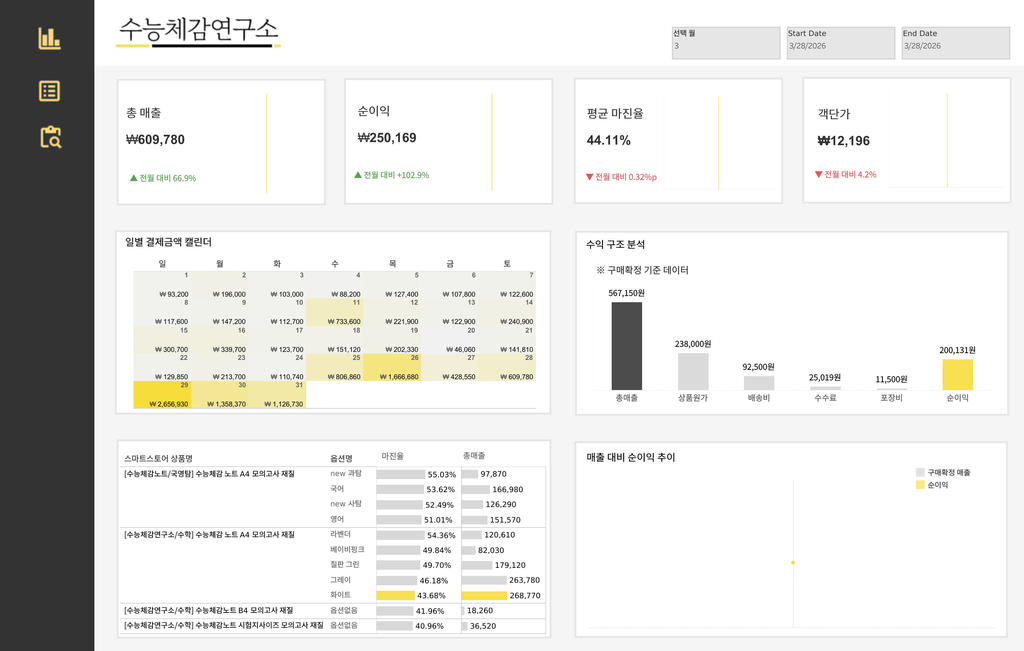

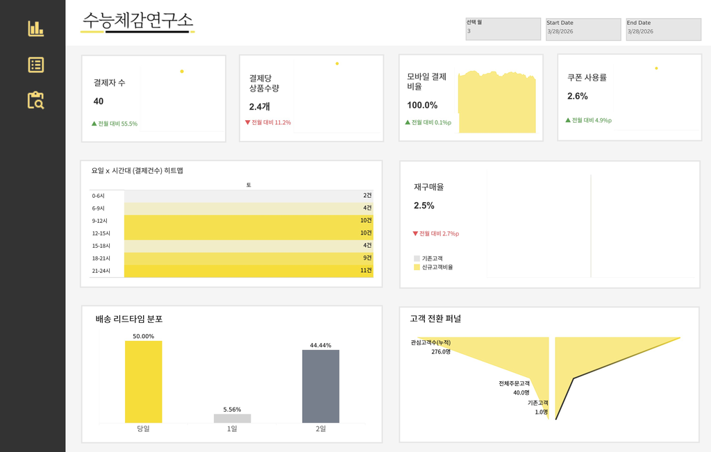

*Left: Mar 28 Launch-Day Profit Margin Dashboard / Right: Mar 28 Launch-Day Sales Operations Dashboard (detail)*

```
Mar 28 (Sat) — Launch Day / "Seeding"
├── 40 purchasers (small group of early adopters)
├── Exam-Paper Size revenue: ₩36,520 (6% of total)
├── Margin: 44.11% (full-price purchases)
├── 44% of orders experienced a two-day shipping delay → weekend fulfillment effect
└── Instagram launch announcement posted
              ↓ 24 hours later
Mar 29 (Sun) — D+1 / "Surge"
├── 146 purchasers (3.65× increase)
├── Exam-Paper Size revenue: ₩1,244,250 (46.8% of total)
├── Coupon usage rate: 8.83% (three-month high)
└── 56 orders concentrated in the Sunday 18–21h window
              ↓ 3 days later
Apr 1 (Wed) — D+4 / "Second Peak"
├── 64 purchasers (stabilization)
├── Exam-Paper Size revenue: ₩384,690 (40.8% of total)
└── Repeat-purchase rate: 11.3% (cross-selling to existing A4 customers)
```

**Data-supported optimal launch formula:**

| Decision | Recommended Choice | Rationale |
| --- | --- | --- |
| Launch day | **Saturday** | Enables a potential D+1 Sunday-evening surge |
| Launch time | **Saturday morning** | Early-adopter purchases from 9–12h can precede social sharing |
| Coupon timing | **D+1 (Sunday) 4–5 PM** | Stimulate demand immediately before the 18–21h purchase peak |
| Follow-up coupon | **D+3–4 (Tue–Wed)** | Leverage the recurring Wednesday late-night purchase pattern |

**Next new product launch scenario:**

```
D-3 (Wed): Instagram teaser — "A new notebook is coming soon"
D-1 (Fri): Instagram Story — "Launching tomorrow"
D+0 (Sat morning): Official launch announcement + Smart Store listing
D+1 (Sun 5 PM): Coupon announcement — "Until midnight today"
D+4 (Wed): Second reminder + inventory update
```

> **One-line takeaway:**  
> “The Exam-Paper Size product launched on Saturday (Mar 28) and surged on Sunday (Mar 29). Revenue rose from ₩36,520 on launch day to ₩1,244,250 within 24 hours, a 34× increase. This pattern is a key feature of the observed new-product launch cycle.”

## 7.6 Insight 6 | Apr 28 (Tue) — ₩794,820 (Late-April Rebound)

**Date:** Apr 28

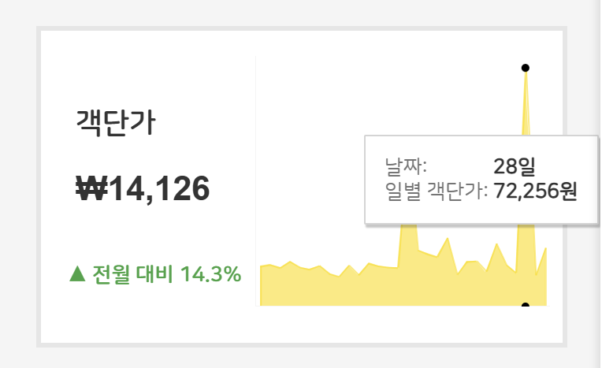

AOV

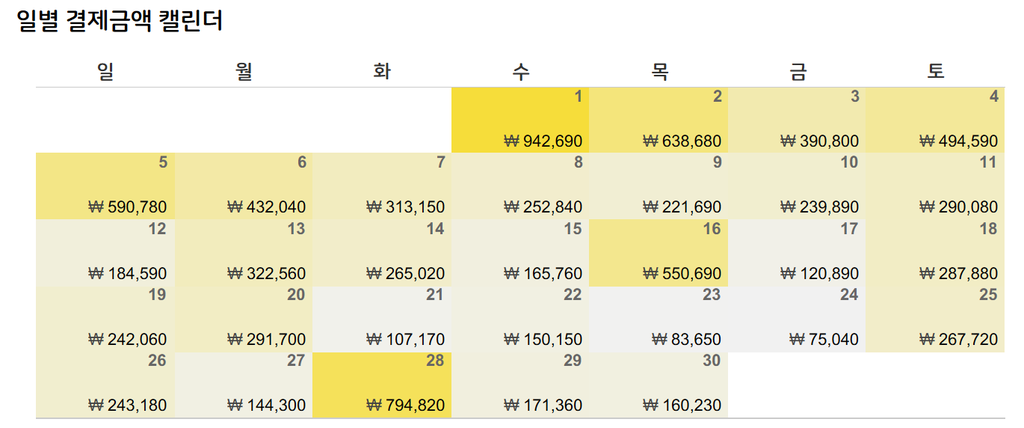

Revenue

**What to investigate:**

The April revenue trend was generally downward before a sudden rebound on Apr 28.

- Check whether a promotion or Instagram post occurred on this date
- April overall AOV: ₩14,126 → Apr 28 AOV: **₩72,256**, an unusually high value consistent with a high-priced item or bundle purchase.

**Why it matters:**

- Purchasers fell 35.2% in April relative to March, creating an overall downward trend.
- Yet revenue rebounded to ₩794,820 on Apr 28, suggesting a specific trigger.
- **Tracing and replicating the trigger could help protect against revenue troughs**

**Strategy point:** If an Instagram post or promotion occurred on Apr 28, formalize and test that intervention as a repeatable tactic.  
A scheduled post on the final Tuesday of each month could be tested as a revenue-trough defense playbook.

**Three-Month Lavender vs. White Margin Trend:**

| Month | Lavender Margin | White Margin | Difference |
| --- | --- | --- | --- |
| February | 50.07% | 47.38% | +2.69 pp |
| March | 49.00% | 43.93% | +5.07 pp |
| April | **51.80%** | **44.26%** | **+7.54 pp** |

**Three-Month Trend Analysis:**

**Confirmed finding:** White remained a high-volume option but consistently had one of the lowest margin structures across all three months.

April Lavender revenue ₩1,632,600 / margin 51.80%  
April White revenue ₩2,915,560 / margin 44.26%

→ Shifting one incremental sale from White toward Lavender would improve per-unit margin, assuming comparable order conditions.

**Additional Timing Insights from Dashboard 2:**

[output not shown]

## 7.8 Summary of Business Insights

[output not shown]

## 7.9 Replicability of the March Peak

**Why March Was the Strongest Month — Replicable Conditions:**

Several factors occurred simultaneously in March:

1. First introduction of coupons (0% → 4.9%)
2. Launch of the Exam-Paper Size product and new options (New Science, New Social Studies, Chalkboard Green)
3. Highest purchaser count (832)
4. Highest repeat-purchase rate (11.1%)

**The combination of a new-product launch and coupon introduction appears to have been central to March performance.**

Coupons remained active in April, but no comparable new-product stimulus occurred, and performance declined.  
→ **Strategy: test a new option or limited edition each month to evaluate whether the March effect can be replicated.**

Examples:

- May → new color option + coupon
- June → CSAT D-100 edition + coupon
- August → special edition before Chuseok + coupon

## 7.10 Monthly Execution Calendar

```
Days 1–17 (organic-sales period)
├── Wednesday 9 PM: publish content
├── Thursday 11 PM: publish a Story
└── Sunday 5 PM: weekly reminder

Days 18–20 (coupon issuance)
├── Target options: Lavender, New Science, Baby Pink
├── Discount rate: 5–10% (apply only to products with ~50%+ margin)
└── Validity: 14 days

Days 26–31 (coupon-harvest period)
├── Thursday night: encourage coupon use
├── Sunday 5 PM: "Ending soon" reminder
└── Returning purchasers: automated follow-up coupon to encourage repeat purchase

New-product launch (Saturday baseline)
├── D-3 (Wed): Instagram teaser
├── D-1 (Fri): "Launching tomorrow" preview
├── D+0 (Sat morning): official launch
├── D+1 (Sun 5 PM): coupon activation
└── D+4 (Wed): second reminder
```

## 7.11 Key Findings by Dashboard

### 7.11.1 Dashboard 1 | Profit Margin Analysis Results

#### 7.11.1.1 Core-Product Selection Matrix — Three-month Result

Using three-month cumulative data, products separate clearly into groups along the two dimensions of revenue scale and margin.

```
              High margin (50%+)
                    ↑
  Lavender(April 51.8%) │  Social Studies(March 56.99%) ★ Top priority
  Baby Pink        │  new Science(52.16%) ★ Top priority
──────────────────────────────────────→ High revenue
  Gray            │  White ← revenue #1, margin lowest
  Chalkboard Green          │
              Low margin (40% range)
```

| Position | Product | Strategic Direction |
| --- | --- | --- |
| ★ Top priority | Social Studies, New Science | Concentrate marketing investment |
| Coupon priority | Lavender, Baby Pink | Margin 50%+ → sufficient room for discounts |
| Strategy shift needed | White, Gray | Increase AOV through bundles |
| Use as an anchor product | Exam-Paper Size | Cross-sell after first-purchase acquisition |

**Key conclusion:** White ranked first in revenue but remained one of the lowest-margin options across all three months. Prioritize marketing toward higher-margin options such as Social Studies and Lavender, while using bundle strategies to raise AOV for White.

#### 7.11.1.2 Shipping-Cost Structure & AOV Strategy

| Month | Shipping Cost / Net Profit | Trend |
| --- | --- | --- |
| February | 53.7% | — |
| March | 50.1% | Improving |
| April | 46.7% | Improving |

Rather than reducing shipping cost in absolute terms, it is more effective to **raise AOV so that shipping represents a smaller share of each order**. With the current AOV of ₩14,126, a free-shipping threshold around ₩30,000 could encourage bundled purchases and structurally improve the shipping-cost share.

### 7.11.2 Dashboard 2 | Sales Operations Analysis Results

#### 7.11.2.1 Three-month Repeat-Purchase Funnel Analysis

| Month | Interested Customers | Purchasers | Conversion Rate | Returning Customers | Repeat-Purchase Rate |
| --- | --- | --- | --- | --- | --- |
| February | 5,772 | 535 | 9.3% | 50 | 9.6% |
| March | 7,830 | 832 | 10.6% | 65 | **11.1%** ← Peak |
| April | **11,037** | 539 | **4.9%** ← Lowest | 59 | 11.0% |

**Key April anomaly:** April had the highest number of interested customers (11,037) but the lowest purchase conversion rate (4.9%).

Awareness is building steadily, but a barrier is discouraging first purchases. First-purchase incentives such as discount coupons or trial bundles are warranted.

The pattern can be verified directly by filtering the following periods in Dashboard 2.

| Check | Filter (start–end date) | What to examine |
| --- | --- | --- |
| March vs. April repeat-purchase rate | Apply 3/1–3/31 and 4/1–4/30 separately | Coupons remained active (~4.7%), but repeat-purchase rate stayed flat → retention tactics beyond coupons are needed |
| Wednesday-night purchase surge | Filter 3/1–3/31 | Wednesday 21–24h orders were 2.8× February levels → recurring late-night purchase pattern |
| Apr 28 purchaser rebound | Filter 4/1–4/30 | Verify the Apr 28 rebound within the broader downward trend and trace its trigger |

#### 7.11.2.2 Optimal Purchase Timing — Three-Month Heatmap Summary

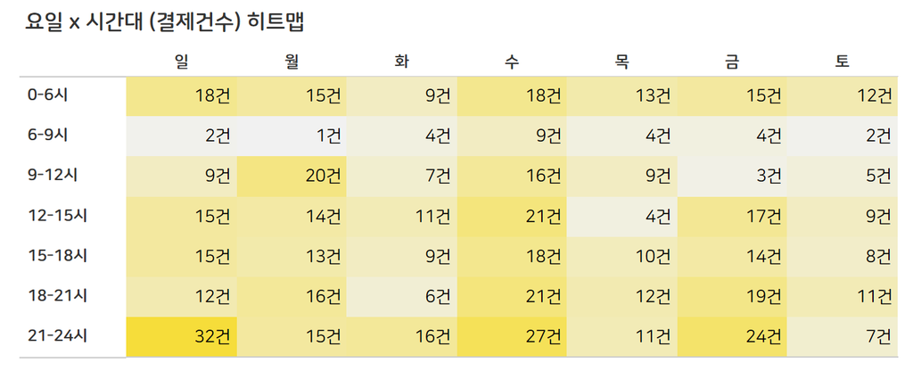

February Purchase Heatmap

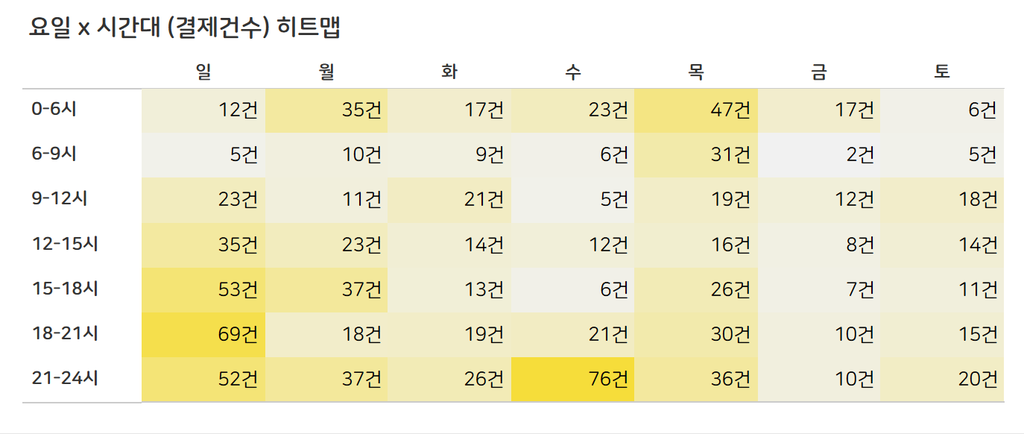

March Purchase Heatmap

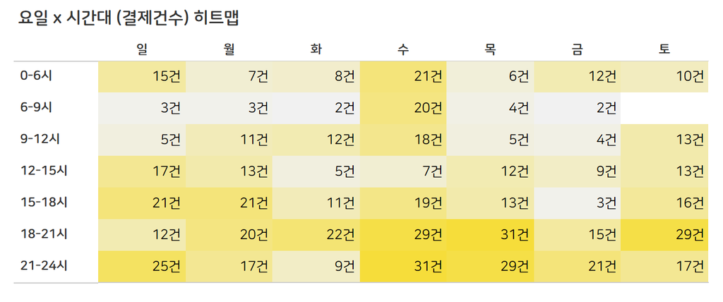

April Purchase Heatmap

| Month | Peak Purchase Window | Orders | Pattern |
| --- | --- | --- | --- |
| February | Sunday 21–24h | 32 | Weekend late night |
| March | Wednesday 21–24h | 76 | Weekday late night |
| April | Wednesday 21–24h | 31 | Weekday late night |

Common three-month pattern: **Purchases concentrate after 9 PM, with recurring Wednesday late-night peaks.**

**21–24h Purchase Pattern:** Purchases were consistently strongest in the 21–24h window. March Wednesday 21–24h reached 76 orders, 2.8× the previous month. Given the repeated Wednesday/Thursday late-night pattern, **publishing Instagram content around 9 PM on Wednesday** appears to be the most promising timing for conversion.

### 7.11.3 Dashboard 3 | Product/Channel Strategy Analysis Results

#### 7.11.3.1 Channel Investment Priority — RPV × CVR

| Channel | CVR | RPV | Investment Priority |
| --- | --- | --- | --- |
| Naver Search | **39%** (6.5× median) | **₩4,592** (6× median) | ★ 1st |
| Shopping (price comparison) | High | High | Optimize thumbnails and reviews |
| Google Search | Low | ₩735 | Reallocate budget to Naver |

**Channel strategy conclusion:** Naver Search is the clear top-priority channel, with both CVR and RPV roughly six times the median. Reallocating part of the Google Ads budget toward Naver Search is therefore more attractive from an ROI perspective.

#### 7.11.3.2 Data Evidence Linking Branding to Sales

| Search Keyword | CVR |
| --- | --- |
| Suneung Chegam Notebook (Korean branded query) | 21.4% |
| **Suneung Chegam Research Lab Notebook (Korean branded query)** | **23.9%** |

Customers searching with the brand name show a higher conversion rate. Interested customers also increased for three consecutive months (5,772 → 7,830 → 11,037), suggesting that brand awareness is increasingly translating into sales.

#### 7.11.3.3 Dual-Target Content Strategy

| Target | Primary Channel | Revenue | Content Direction |
| --- | --- | --- | --- |
| Exam-takers (17–19) | Shopping | ₩3,455,490 | Exam-taker empathy-focused content |
| Parents (46–50) | Shopping | ₩3,301,460 | “Gift for a child” messaging |

Shopping revenue from parents aged 46–50 is comparable to that of exam-takers, suggesting meaningful parent-led purchasing. A dual-target strategy should therefore combine exam-taker-focused content with messaging positioned as a gift for one’s child.

## 7.12 Integrated Action Plan

| Strategy | Current State | Target State | Expected Impact |
| --- | --- | --- | --- |
| Optimize coupon timing | Irregular issuance | Fixed issuance on the 18th–20th each month | Sustain late-month revenue concentration |
| Redesign coupon targeting | Coupons concentrated on low-margin products | Prioritize Social Studies, Lavender, and Science | Improve net profit with the same coupon spend |
| Shift White/Gray strategy | Primarily single-item sales | 10-unit bundle promotion | Improve box utilization and narrow margin gaps |
| Build repeat-purchase cycle | Customer drop-off after the first purchase | Automated follow-up coupon | Target repeat-purchase rate of 15%+ |
| Reallocate channel investment | Instagram-only dependence | Add Naver Search advertising | Scale a channel with 39% CVR |
| Standardize new-product launch process | Unstructured launches | Two-stage Sat→Sun launch | Replicate the D+1 launch surge |
| Increase AOV | ₩12,000–14,000 | ₩20,000+ bundle design | Reduce shipping cost as a share of order value |
| Protect revenue troughs | Irregular content | Scheduled content on the final Tuesday of each month | Test whether the Apr 28 rebound can be reproduced |

*Analysis period: Feb 1–Apr 30, 2026 | Data source: Naver Smart Store Center | Tool: Tableau*